# Nvidia stock price forecast

# ARIMA

```python
def arima_model_init(params):
    return StatsForecast(
        freq='D',
        models=[
            AutoARIMA(),
        ]
    )
```

```python
arima_model = arima_model_init(None)
arima_model.fit(train_with_exogenous)
```

```
StatsForecast(models=[AutoARIMA])
```

Plot and analyze residuals of the model

```python
#get result to analyze residuals later
arima_result=arima_model.fitted_[0,0].model_
arima_result
```

[output not shown]

[output cut: 324 more lines]

[output not shown]

```python
arima_name = arima_string(arima_result)
arima_name
```

```
'Regression with ARIMA(2,1,3) errors'
```

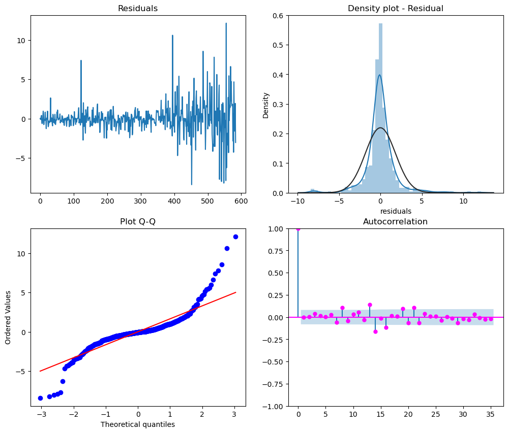

```python
fitted_arima_predictions = pd.DataFrame(arima_result.get("residuals"), columns=["residuals"])
plot_residuals(fitted_arima_predictions['residuals'])
```

Out-of-sample forecasts

```python
arima_predictions = arima_model.predict(len(test), X_df=future_exogenous)

arima_predictions.set_index(test.index, inplace=True)
```

```python
fig = px.line(title="Closing stock prices (daily)")
fig.add_scatter(x=train['ds'], y=train['y'], mode='lines', name='train', line=dict(color='blue'))
fig.add_scatter(x=test['ds'], y=test['y'], mode='lines', name='test', line=dict(color='green'))
fig.add_scatter(x=arima_predictions['ds'], y=arima_predictions['AutoARIMA'], mode='lines', name='prediction', line=dict(color='red'))

fig.update_layout(template='plotly_white', width=1000, height=500)
fig.update_xaxes(title_text="date")
fig.update_yaxes(title_text="closing price")
fig.show()
```

[interactive chart not shown]

Calculate quality metric by using MAPE

```python
arima_mape = my_mape(arima_predictions['AutoARIMA'], test['y'])
```

```python
model_metrics_logger.info(
    f'Model name: {arima_name}, MAPE score: {arima_mape}'
)
```

```
Model name: Regression with ARIMA(2,1,3) errors, MAPE score: 6.159700948191057
```

# Prophet

Find best hyperparameters using grid serach and expanding window cross-validation

```python
def prophet_model_init(params):

    m = fp.Prophet(**params, yearly_seasonality = False, weekly_seasonality = False)
    m.add_regressor("fedfunds")
    m.add_regressor("unrate")

    return m
```

```python
def prophet_cv_score(model):

    model.fit(train_with_exogenous)
    cv_results = cross_validation(model, initial='384 days', period='40 days', horizon = '40 days', parallel="processes")
    df_p = performance_metrics(cv_results, rolling_window=1)
    return df_p.loc[0, 'mape']
```

```python
prophet_grid_search = GridSearch(
    all_params={
        'changepoint_prior_scale': [0.005, 0.01, 0.05, 0.25],
        'n_changepoints': [10, 25, 50],
        'changepoint_range': [0.7, 0.8, 0.9, 0.95]
    },
    model_initializer=prophet_model_init,
    calculate_score=prophet_cv_score
)
```

```python
prophet_grid_search.search()
```

```
18:59:31 - cmdstanpy - INFO - Chain [1] start processing
18:59:31 - cmdstanpy - INFO - Chain [1] done processing
18:59:33 - cmdstanpy - INFO - Chain [1] start processing
18:59:34 - cmdstanpy - INFO - Chain [1] done processing
```

```
Iteration: 1 of 48
	Params: {'changepoint_prior_scale': 0.005, 'n_changepoints': 10, 'changepoint_range': 0.7}
	Score: 0.12656807894463903
```

```
18:59:36 - cmdstanpy - INFO - Chain [1] start processing
18:59:36 - cmdstanpy - INFO - Chain [1] done processing
```

```
Iteration: 2 of 48
	Params: {'changepoint_prior_scale': 0.005, 'n_changepoints': 10, 'changepoint_range': 0.8}
	Score: 0.1276361021655181
```

```
18:59:38 - cmdstanpy - INFO - Chain [1] start processing
18:59:38 - cmdstanpy - INFO - Chain [1] done processing
```

```
Iteration: 3 of 48
	Params: {'changepoint_prior_scale': 0.005, 'n_changepoints': 10, 'changepoint_range': 0.9}
	Score: 0.12579062252520817
```

```
18:59:41 - cmdstanpy - INFO - Chain [1] start processing
```

```
Iteration: 4 of 48
	Params: {'changepoint_prior_scale': 0.005, 'n_changepoints': 10, 'changepoint_range': 0.95}
	Score: 0.12623627687142067
```

```
18:59:41 - cmdstanpy - INFO - Chain [1] done processing
18:59:44 - cmdstanpy - INFO - Chain [1] start processing
18:59:44 - cmdstanpy - INFO - Chain [1] done processing
```

```
Iteration: 5 of 48
	Params: {'changepoint_prior_scale': 0.005, 'n_changepoints': 25, 'changepoint_range': 0.7}
	Score: 0.12897779526968728
```

```
18:59:46 - cmdstanpy - INFO - Chain [1] start processing
18:59:46 - cmdstanpy - INFO - Chain [1] done processing
```

```
Iteration: 6 of 48
	Params: {'changepoint_prior_scale': 0.005, 'n_changepoints': 25, 'changepoint_range': 0.8}
	Score: 0.14404786440814463
```

```
18:59:49 - cmdstanpy - INFO - Chain [1] start processing
18:59:49 - cmdstanpy - INFO - Chain [1] done processing
```

```
Iteration: 7 of 48
	Params: {'changepoint_prior_scale': 0.005, 'n_changepoints': 25, 'changepoint_range': 0.9}
	Score: 0.12987306667777537
```

```
18:59:51 - cmdstanpy - INFO - Chain [1] start processing
18:59:51 - cmdstanpy - INFO - Chain [1] done processing
```

```
Iteration: 8 of 48
	Params: {'changepoint_prior_scale': 0.005, 'n_changepoints': 25, 'changepoint_range': 0.95}
	Score: 0.13247771431995622
```

```
18:59:54 - cmdstanpy - INFO - Chain [1] start processing
18:59:54 - cmdstanpy - INFO - Chain [1] done processing
```

```
Iteration: 9 of 48
	Params: {'changepoint_prior_scale': 0.005, 'n_changepoints': 50, 'changepoint_range': 0.7}
	Score: 0.1317420467253153
```

```
18:59:56 - cmdstanpy - INFO - Chain [1] start processing
```

```
Iteration: 10 of 48
	Params: {'changepoint_prior_scale': 0.005, 'n_changepoints': 50, 'changepoint_range': 0.8}
	Score: 0.12998971565566408
```

```
18:59:56 - cmdstanpy - INFO - Chain [1] done processing
18:59:59 - cmdstanpy - INFO - Chain [1] start processing
18:59:59 - cmdstanpy - INFO - Chain [1] done processing
```

```
Iteration: 11 of 48
	Params: {'changepoint_prior_scale': 0.005, 'n_changepoints': 50, 'changepoint_range': 0.9}
	Score: 0.12945247095464535
```

```
19:00:01 - cmdstanpy - INFO - Chain [1] start processing
19:00:01 - cmdstanpy - INFO - Chain [1] done processing
```

```
Iteration: 12 of 48
	Params: {'changepoint_prior_scale': 0.005, 'n_changepoints': 50, 'changepoint_range': 0.95}
	Score: 0.12851363215377748
```

```
19:00:04 - cmdstanpy - INFO - Chain [1] start processing
```

```
Iteration: 13 of 48
	Params: {'changepoint_prior_scale': 0.01, 'n_changepoints': 10, 'changepoint_range': 0.7}
	Score: 0.102053869534846
```

```
19:00:04 - cmdstanpy - INFO - Chain [1] done processing
19:00:07 - cmdstanpy - INFO - Chain [1] start processing
19:00:07 - cmdstanpy - INFO - Chain [1] done processing
```

```
Iteration: 14 of 48
	Params: {'changepoint_prior_scale': 0.01, 'n_changepoints': 10, 'changepoint_range': 0.8}
	Score: 0.12035897538027654
```

```
19:00:09 - cmdstanpy - INFO - Chain [1] start processing
```

```
Iteration: 15 of 48
	Params: {'changepoint_prior_scale': 0.01, 'n_changepoints': 10, 'changepoint_range': 0.9}
	Score: 0.1206074567551579
```

```
19:00:09 - cmdstanpy - INFO - Chain [1] done processing
19:00:12 - cmdstanpy - INFO - Chain [1] start processing
```

```
Iteration: 16 of 48
	Params: {'changepoint_prior_scale': 0.01, 'n_changepoints': 10, 'changepoint_range': 0.95}
	Score: 0.11798731084335412
```

```
19:00:12 - cmdstanpy - INFO - Chain [1] done processing
19:00:14 - cmdstanpy - INFO - Chain [1] start processing
```

```
Iteration: 17 of 48
	Params: {'changepoint_prior_scale': 0.01, 'n_changepoints': 25, 'changepoint_range': 0.7}
	Score: 0.10308914186043079
```

```
19:00:15 - cmdstanpy - INFO - Chain [1] done processing
19:00:17 - cmdstanpy - INFO - Chain [1] start processing
19:00:17 - cmdstanpy - INFO - Chain [1] done processing
```

```
Iteration: 18 of 48
	Params: {'changepoint_prior_scale': 0.01, 'n_changepoints': 25, 'changepoint_range': 0.8}
	Score: 0.11733086528002465
```

```
19:00:20 - cmdstanpy - INFO - Chain [1] start processing
```

```
Iteration: 19 of 48
	Params: {'changepoint_prior_scale': 0.01, 'n_changepoints': 25, 'changepoint_range': 0.9}
	Score: 0.1265526854155944
```

```
19:00:20 - cmdstanpy - INFO - Chain [1] done processing
19:00:22 - cmdstanpy - INFO - Chain [1] start processing
```

```
Iteration: 20 of 48
	Params: {'changepoint_prior_scale': 0.01, 'n_changepoints': 25, 'changepoint_range': 0.95}
	Score: 0.12670111133876977
```

```
19:00:22 - cmdstanpy - INFO - Chain [1] done processing
19:00:25 - cmdstanpy - INFO - Chain [1] start processing
```

```
Iteration: 21 of 48
	Params: {'changepoint_prior_scale': 0.01, 'n_changepoints': 50, 'changepoint_range': 0.7}
	Score: 0.10434537683891373
```

```
19:00:25 - cmdstanpy - INFO - Chain [1] done processing
19:00:27 - cmdstanpy - INFO - Chain [1] start processing
```

```
Iteration: 22 of 48
	Params: {'changepoint_prior_scale': 0.01, 'n_changepoints': 50, 'changepoint_range': 0.8}
	Score: 0.11540054288920595
```

```
19:00:28 - cmdstanpy - INFO - Chain [1] done processing
19:00:30 - cmdstanpy - INFO - Chain [1] start processing
```

```
Iteration: 23 of 48
	Params: {'changepoint_prior_scale': 0.01, 'n_changepoints': 50, 'changepoint_range': 0.9}
	Score: 0.12379139546561946
```

```
19:00:30 - cmdstanpy - INFO - Chain [1] done processing
19:00:33 - cmdstanpy - INFO - Chain [1] start processing
19:00:33 - cmdstanpy - INFO - Chain [1] done processing
```

```
Iteration: 24 of 48
	Params: {'changepoint_prior_scale': 0.01, 'n_changepoints': 50, 'changepoint_range': 0.95}
	Score: 0.12388507829914008
```

```
19:00:35 - cmdstanpy - INFO - Chain [1] start processing
```

```
Iteration: 25 of 48
	Params: {'changepoint_prior_scale': 0.05, 'n_changepoints': 10, 'changepoint_range': 0.7}
	Score: 0.107979489389522
```

```
19:00:35 - cmdstanpy - INFO - Chain [1] done processing
19:00:38 - cmdstanpy - INFO - Chain [1] start processing
```

```
Iteration: 26 of 48
	Params: {'changepoint_prior_scale': 0.05, 'n_changepoints': 10, 'changepoint_range': 0.8}
	Score: 0.13627154499815203
```

```
19:00:38 - cmdstanpy - INFO - Chain [1] done processing
19:00:41 - cmdstanpy - INFO - Chain [1] start processing
```

```
Iteration: 27 of 48
	Params: {'changepoint_prior_scale': 0.05, 'n_changepoints': 10, 'changepoint_range': 0.9}
	Score: 0.1583907473289331
```

```
19:00:41 - cmdstanpy - INFO - Chain [1] done processing
19:00:43 - cmdstanpy - INFO - Chain [1] start processing
```

```
Iteration: 28 of 48
	Params: {'changepoint_prior_scale': 0.05, 'n_changepoints': 10, 'changepoint_range': 0.95}
	Score: 0.17744094264743432
```

```
19:00:44 - cmdstanpy - INFO - Chain [1] done processing
19:00:46 - cmdstanpy - INFO - Chain [1] start processing
```

```
Iteration: 29 of 48
	Params: {'changepoint_prior_scale': 0.05, 'n_changepoints': 25, 'changepoint_range': 0.7}
	Score: 0.10698487484243875
```

```
19:00:46 - cmdstanpy - INFO - Chain [1] done processing
19:00:49 - cmdstanpy - INFO - Chain [1] start processing
```

```
Iteration: 30 of 48
	Params: {'changepoint_prior_scale': 0.05, 'n_changepoints': 25, 'changepoint_range': 0.8}
	Score: 0.13700851518311585
```

```
19:00:49 - cmdstanpy - INFO - Chain [1] done processing
19:00:51 - cmdstanpy - INFO - Chain [1] start processing
```

```
Iteration: 31 of 48
	Params: {'changepoint_prior_scale': 0.05, 'n_changepoints': 25, 'changepoint_range': 0.9}
	Score: 0.1776998438180514
```

```
19:00:52 - cmdstanpy - INFO - Chain [1] done processing
19:00:54 - cmdstanpy - INFO - Chain [1] start processing
```

```
Iteration: 32 of 48
	Params: {'changepoint_prior_scale': 0.05, 'n_changepoints': 25, 'changepoint_range': 0.95}
	Score: 0.17274400800966108
```

```
19:00:54 - cmdstanpy - INFO - Chain [1] done processing
19:00:57 - cmdstanpy - INFO - Chain [1] start processing
```

```
Iteration: 33 of 48
	Params: {'changepoint_prior_scale': 0.05, 'n_changepoints': 50, 'changepoint_range': 0.7}
	Score: 0.10597478840010466
```

```
19:00:57 - cmdstanpy - INFO - Chain [1] done processing
19:00:59 - cmdstanpy - INFO - Chain [1] start processing
```

```
Iteration: 34 of 48
	Params: {'changepoint_prior_scale': 0.05, 'n_changepoints': 50, 'changepoint_range': 0.8}
	Score: 0.13530275686934792
```

```
19:01:00 - cmdstanpy - INFO - Chain [1] done processing
19:01:02 - cmdstanpy - INFO - Chain [1] start processing
```

```
Iteration: 35 of 48
	Params: {'changepoint_prior_scale': 0.05, 'n_changepoints': 50, 'changepoint_range': 0.9}
	Score: 0.17501814904481686
```

```
19:01:02 - cmdstanpy - INFO - Chain [1] done processing
19:01:05 - cmdstanpy - INFO - Chain [1] start processing
```

```
Iteration: 36 of 48
	Params: {'changepoint_prior_scale': 0.05, 'n_changepoints': 50, 'changepoint_range': 0.95}
	Score: 0.16418454670947447
```

```
19:01:05 - cmdstanpy - INFO - Chain [1] done processing
19:01:08 - cmdstanpy - INFO - Chain [1] start processing
```

```
Iteration: 37 of 48
	Params: {'changepoint_prior_scale': 0.25, 'n_changepoints': 10, 'changepoint_range': 0.7}
	Score: 0.10713017426566754
```

```
19:01:08 - cmdstanpy - INFO - Chain [1] done processing
19:01:11 - cmdstanpy - INFO - Chain [1] start processing
```

```
Iteration: 38 of 48
	Params: {'changepoint_prior_scale': 0.25, 'n_changepoints': 10, 'changepoint_range': 0.8}
	Score: 0.14827834718870642
```

```
19:01:11 - cmdstanpy - INFO - Chain [1] done processing
19:01:14 - cmdstanpy - INFO - Chain [1] start processing
```

```
Iteration: 39 of 48
	Params: {'changepoint_prior_scale': 0.25, 'n_changepoints': 10, 'changepoint_range': 0.9}
	Score: 0.18199548989398193
```

```
19:01:14 - cmdstanpy - INFO - Chain [1] done processing
19:01:16 - cmdstanpy - INFO - Chain [1] start processing
```

```
Iteration: 40 of 48
	Params: {'changepoint_prior_scale': 0.25, 'n_changepoints': 10, 'changepoint_range': 0.95}
	Score: 0.2019128047608878
```

```
19:01:17 - cmdstanpy - INFO - Chain [1] done processing
19:01:19 - cmdstanpy - INFO - Chain [1] start processing
```

```
Iteration: 41 of 48
	Params: {'changepoint_prior_scale': 0.25, 'n_changepoints': 25, 'changepoint_range': 0.7}
	Score: 0.1068273717748085
```

```
19:01:19 - cmdstanpy - INFO - Chain [1] done processing
19:01:22 - cmdstanpy - INFO - Chain [1] start processing
```

```
Iteration: 42 of 48
	Params: {'changepoint_prior_scale': 0.25, 'n_changepoints': 25, 'changepoint_range': 0.8}
	Score: 0.15284508744798292
```

```
19:01:22 - cmdstanpy - INFO - Chain [1] done processing
19:01:25 - cmdstanpy - INFO - Chain [1] start processing
```

```
Iteration: 43 of 48
	Params: {'changepoint_prior_scale': 0.25, 'n_changepoints': 25, 'changepoint_range': 0.9}
	Score: 0.1779384129561728
```

```
19:01:25 - cmdstanpy - INFO - Chain [1] done processing
19:01:28 - cmdstanpy - INFO - Chain [1] start processing
```

```
Iteration: 44 of 48
	Params: {'changepoint_prior_scale': 0.25, 'n_changepoints': 25, 'changepoint_range': 0.95}
	Score: 0.17277982426841404
```

```
19:01:28 - cmdstanpy - INFO - Chain [1] done processing
19:01:31 - cmdstanpy - INFO - Chain [1] start processing
```

```
Iteration: 45 of 48
	Params: {'changepoint_prior_scale': 0.25, 'n_changepoints': 50, 'changepoint_range': 0.7}
	Score: 0.10665037171571087
```

```
19:01:31 - cmdstanpy - INFO - Chain [1] done processing
19:01:34 - cmdstanpy - INFO - Chain [1] start processing
```

```
Iteration: 46 of 48
	Params: {'changepoint_prior_scale': 0.25, 'n_changepoints': 50, 'changepoint_range': 0.8}
	Score: 0.15327198017365212
```

```
19:01:34 - cmdstanpy - INFO - Chain [1] done processing
19:01:37 - cmdstanpy - INFO - Chain [1] start processing
```

```
Iteration: 47 of 48
	Params: {'changepoint_prior_scale': 0.25, 'n_changepoints': 50, 'changepoint_range': 0.9}
	Score: 0.17284624229202028
```

```
19:01:37 - cmdstanpy - INFO - Chain [1] done processing
```

```
Iteration: 48 of 48
	Params: {'changepoint_prior_scale': 0.25, 'n_changepoints': 50, 'changepoint_range': 0.95}
	Score: 0.17571847948567268
Best score: 0.102053869534846
	with params {'changepoint_prior_scale': 0.01, 'n_changepoints': 10, 'changepoint_range': 0.7}
```

```python
prophet_grid_search.display_results()
```

|  | score | changepoint_prior_scale | n_changepoints | changepoint_range |
| --- | --- | --- | --- | --- |
| 12 | 0.102054 | 0.010 | 10 | 0.70 |
| 16 | 0.103089 | 0.010 | 25 | 0.70 |
| 20 | 0.104345 | 0.010 | 50 | 0.70 |
| 32 | 0.105975 | 0.050 | 50 | 0.70 |
| 44 | 0.106650 | 0.250 | 50 | 0.70 |
| 40 | 0.106827 | 0.250 | 25 | 0.70 |
| 28 | 0.106985 | 0.050 | 25 | 0.70 |
| 36 | 0.107130 | 0.250 | 10 | 0.70 |
| 24 | 0.107979 | 0.050 | 10 | 0.70 |
| 21 | 0.115401 | 0.010 | 50 | 0.80 |
| 17 | 0.117331 | 0.010 | 25 | 0.80 |
| 15 | 0.117987 | 0.010 | 10 | 0.95 |
| 13 | 0.120359 | 0.010 | 10 | 0.80 |
| 14 | 0.120607 | 0.010 | 10 | 0.90 |
| 22 | 0.123791 | 0.010 | 50 | 0.90 |
| 23 | 0.123885 | 0.010 | 50 | 0.95 |
| 2 | 0.125791 | 0.005 | 10 | 0.90 |
| 3 | 0.126236 | 0.005 | 10 | 0.95 |
| 18 | 0.126553 | 0.010 | 25 | 0.90 |
| 0 | 0.126568 | 0.005 | 10 | 0.70 |
| 19 | 0.126701 | 0.010 | 25 | 0.95 |
| 1 | 0.127636 | 0.005 | 10 | 0.80 |
| 11 | 0.128514 | 0.005 | 50 | 0.95 |
| 4 | 0.128978 | 0.005 | 25 | 0.70 |
| 10 | 0.129452 | 0.005 | 50 | 0.90 |
| 6 | 0.129873 | 0.005 | 25 | 0.90 |
| 9 | 0.129990 | 0.005 | 50 | 0.80 |
| 8 | 0.131742 | 0.005 | 50 | 0.70 |
| 7 | 0.132478 | 0.005 | 25 | 0.95 |
| 33 | 0.135303 | 0.050 | 50 | 0.80 |
| 25 | 0.136272 | 0.050 | 10 | 0.80 |
| 29 | 0.137009 | 0.050 | 25 | 0.80 |
| 5 | 0.144048 | 0.005 | 25 | 0.80 |
| 37 | 0.148278 | 0.250 | 10 | 0.80 |
| 41 | 0.152845 | 0.250 | 25 | 0.80 |
| 45 | 0.153272 | 0.250 | 50 | 0.80 |
| 26 | 0.158391 | 0.050 | 10 | 0.90 |
| 35 | 0.164185 | 0.050 | 50 | 0.95 |
| 31 | 0.172744 | 0.050 | 25 | 0.95 |
| 43 | 0.172780 | 0.250 | 25 | 0.95 |
| 46 | 0.172846 | 0.250 | 50 | 0.90 |
| 34 | 0.175018 | 0.050 | 50 | 0.90 |
| 47 | 0.175718 | 0.250 | 50 | 0.95 |
| 27 | 0.177441 | 0.050 | 10 | 0.95 |
| 30 | 0.177700 | 0.050 | 25 | 0.90 |
| 42 | 0.177938 | 0.250 | 25 | 0.90 |
| 38 | 0.181995 | 0.250 | 10 | 0.90 |
| 39 | 0.201913 | 0.250 | 10 | 0.95 |

Let's fit the best model

```python
prophet_model = prophet_model_init(prophet_grid_search.get_best_params())

prophet_model.fit(train_with_exogenous)

future = prophet_model.make_future_dataframe(periods=len(test))

future = future.merge(
    pd.concat([
        train_with_exogenous[['ds', 'fedfunds', 'unrate']],
        future_exogenous
    ]),
    left_on='ds',
    right_on='ds'
)

forecast_prophet = prophet_model.predict(future)
```

```
19:01:40 - cmdstanpy - INFO - Chain [1] start processing
19:01:40 - cmdstanpy - INFO - Chain [1] done processing
```

Plot and analyze residuals of the model

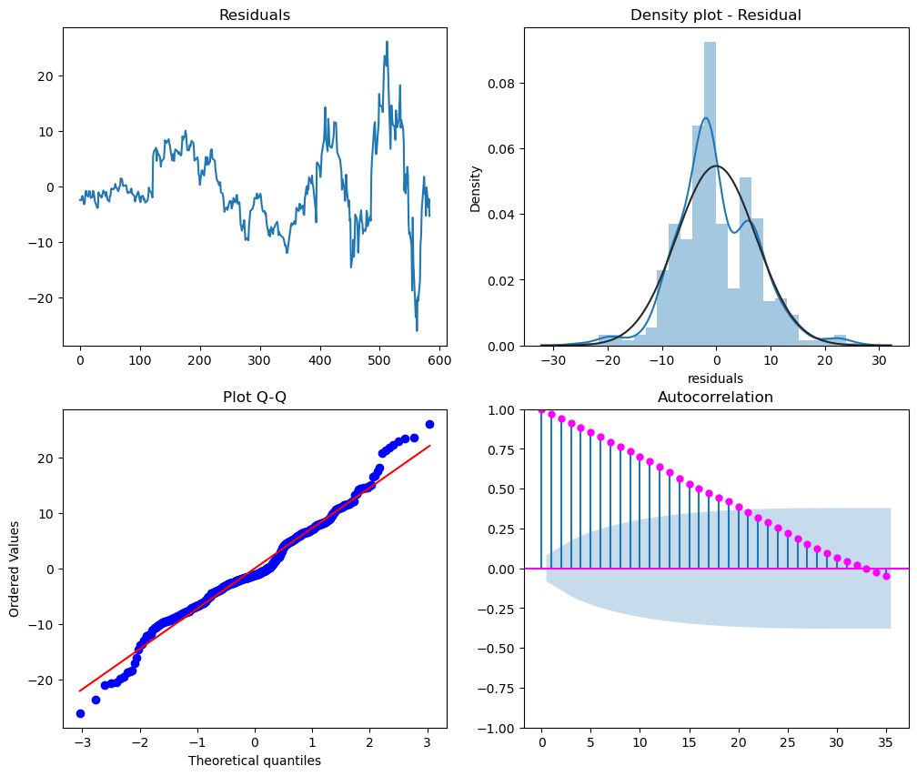

```python
fitted_forecast_prophet = pd.DataFrame(train_with_exogenous['y'] - forecast_prophet[:len(train)]['yhat'], columns=["residuals"])
plot_residuals(fitted_forecast_prophet['residuals'])
```

```python
fig = px.line(title="Closing stock prices (daily)")
fig.add_scatter(x=train['ds'], y=train['y'], mode='lines', name='train', line=dict(color='blue'))
fig.add_scatter(x=test['ds'], y=test['y'], mode='lines', name='test', line=dict(color='green'))
fig.add_scatter(x=forecast_prophet['ds'], y=forecast_prophet['yhat'], mode='lines', name='prediction', line=dict(color='red'))

fig.update_layout(template='plotly_white', width=1000, height=500)
fig.update_xaxes(title_text="date")
fig.update_yaxes(title_text="closing price")
fig.show()
```

[interactive chart not shown]

Calculate quality metric by using MAPE

```python
prophet_mape = my_mape(forecast_prophet['yhat'], test['y'])
```

```python
model_metrics_logger.info(
    f'Model name: Prophet, MAPE score: {prophet_mape}, hyperparameters: {prophet_grid_search.get_best_params()}'
)
```

```
Model name: Prophet, MAPE score: 12.589651917074644, hyperparameters: {'changepoint_prior_scale': 0.01, 'n_changepoints': 10, 'changepoint_range': 0.7}
```

# Summary

In this work, I downloaded Nvidia's closing stock price, prepared data to work with MLForecast, NeuralForecast, and StatsForecast, and Prophet modules. Then split the data into train and test. Performed autocorrelation and stationarity analysis, came up with the conclusion that required making first-order differencing to make the time series stationary, and only one previous lag correlated with current. Then I tried five models: Linear Regression, XGBoost, ARIMA, LSTM, and Prophet, and found the best hyperparameters using grid search and cross-validation on train data. And finally fit the models on the whole training data, make predictions, and calculate the MAPE score on test data.